# What Python Project Should I Build Next? What Job Postings Suggest

web scraping

labor market

R

Author

Michael Li

Published

September 20, 2026

## The question

When I started learning Python as a college freshman, deciding what to build next was not obvious. Backend development, databases, and machine learning all seemed useful, but I wanted a project with a clear purpose.

By “build,” I mean completing a small, working Python project that I could include in a portfolio to show what I can do. An application tracker or a simple machine learning classifier would be examples. I wanted to use job postings to help narrow that choice, and I thought the same exercise could be useful to other learners deciding how to put their Python knowledge into practice.

So my question is: what do the topic tags on Python job postings suggest about whether a beginner should start with a backend application or a machine learning project?

But only looking at job postings online cannot tell me which project will get someone hired. They can give me a limited view of the work employers advertise and help me make a more informed learning choice.

## Collecting the data

So I decide to use the public [Python.org Job Board](https://www.python.org/jobs/) and collect only its first listing page. Each row represents one listing URL. I will extract the title, location, topic tags, posting dates, and links.

I use R to read the webpage, identify the repeated job cards, and extract the same fields from each card. A selector tells R where to find information such as a job title or its topic tags. This turns the listings into a table that I can compare systematically.

For ethical collection as required, the code does not bypass logins, CAPTCHAs, paywalls, or other access restrictions. If the website denies access, I would stop collecting.

```r
url <- "https://www.python.org/jobs/"
html_file <- file.path(data_dir, "python_jobs.html")
metadata_file <- file.path(data_dir, "collection_metadata.csv")

# Set it FALSE will reuse the snapshot. If none exists, collect one page.
# I will set it TRUE only if when I want to deliberately collecting a new snapshot.
refresh <- FALSE
new_snapshot <- refresh || !file.exists(html_file)

if (new_snapshot) {
  page <- read_html(url)
} else {
  page <- read_html(html_file)
}

job_cards <- page |> html_elements("ol.list-recent-jobs > li")

if (length(job_cards) == 0) {
  stop("No job cards found. Check the page before continuing.")
}

jobs_raw <- tibble(
  title = job_cards |>
    html_element(".listing-company-name a") |> html_text2(),
  location = job_cards |>
    html_element(".listing-location") |> html_text2(),
  tags = job_cards |>
    html_element(".listing-job-type") |> html_text2(),
  posted_date = job_cards |>
    html_element("time") |> html_attr("datetime"),
  job_url = job_cards |>
    html_element(".listing-company-name a") |> html_attr("href")
)

jobs_raw <- jobs_raw |>
  mutate(job_url = xml2::url_absolute(job_url, url))

if (any(is.na(jobs_raw$title) | str_squish(jobs_raw$title) == "") ||
    any(is.na(jobs_raw$job_url) | jobs_raw$job_url == "")) {
  stop("A title or link is missing. Check the extraction before continuing.")
}

if (new_snapshot) {
  metadata <- tibble(
    source_url = url,
    snapshot_date_utc = format(Sys.time(), "%Y-%m-%d", tz = "UTC"),
    retrieval_method = "Downloaded with rvest::read_html(url)",
    scope = "First listing page only"
  )
  xml2::write_html(page, html_file)
  write_csv(metadata, metadata_file)
} else {
  metadata <- read_csv(metadata_file, show_col_types = FALSE)
}

snapshot_date <- metadata$snapshot_date_utc[1]

# Display the first five collected listings.
knitr::kable(
  jobs_raw |> select(title, location, posted_date) |> head(5),
  col.names = c("Job title", "Location", "Posting date"),
  caption = "First five collected listings"
)
```

First five collected listings

| Job title | Location | Posting date |
| --- | --- | --- |
| Django Developer | Birmingham, United Kingdom | 2026-09-16T14:49:25.631267+00:00 |
| ML Engineer | Remote, Worlwide, Worldwide | 2026-09-15T12:25:57.866201+00:00 |
| Software Engineer, Full Stack (Python, Java, Rust, C#, C++) | Remote, Remote, Worldwide | 2026-09-11T07:04:40.449482+00:00 |
| Agentic Python Engineer | Remote, Remote/Worldwide, Remote/Worldwide, Remote | 2026-09-08T15:45:59.797261+00:00 |
| Software Engineer | Remote, United States of America | 2026-09-03T23:03:08.659965+00:00 |

The snapshot I used here was collected on 2026-09-20 (UTC) and contains 25 job cards. It is a snapshot of one page, not the entire Python job market.

## Cleaning the information

Now I want to remove all extra spaces, convert the posting dates, and remove duplicate URLs. I also record which listings have no topic tags. Missing tags are missing information, so they do not show that a job requires none of these skills.

I mainly focus on six broad labels: Back end, Machine Learning, Database, Front end, Cloud, and Web. I selected these labels to compare backend and machine learning with related areas that could become part of a Python project. They are not an exhaustive list of employers’ requirements. `str_detect()` checks whether each label appears, and `sum()` later counts the TRUE values.

```r
jobs <- jobs_raw |>
  mutate(
    title = str_squish(title),
    location = str_squish(location),
    tags = coalesce(str_squish(tags), ""),
    tags_missing = tags == "",
    posted_date = as.Date(substr(posted_date, 1, 10))
  ) |>
  distinct(job_url, .keep_all = TRUE) |>
  mutate(
    backend = str_detect(tags, fixed("Back end", ignore_case = TRUE)),
    machine_learning = str_detect(tags, fixed("Machine Learning", ignore_case = TRUE)),
    database = str_detect(tags, fixed("Database", ignore_case = TRUE)),
    frontend = str_detect(tags, fixed("Front end", ignore_case = TRUE)),
    cloud = str_detect(tags, fixed("Cloud", ignore_case = TRUE)),
    web = str_detect(tags, fixed("Web", ignore_case = TRUE))
  )

#save the cleaned data
write.csv(
  jobs,
  here("blog", "posts", "post2", "data", "jobs_clean.csv"),
  row.names = FALSE
)

#read the saved data for the analysis
jobs <- read.csv(
  here("blog", "posts", "post2", "data", "jobs_clean.csv"),
  stringsAsFactors = FALSE
)

#convert posting dates back to dates after reading the CSV
jobs$posted_date <- as.Date(jobs$posted_date)

n_total <- nrow(jobs)
n_duplicates <- nrow(jobs_raw) - n_total
n_missing <- sum(jobs$tags_missing)
n_missing_dates <- sum(is.na(jobs$posted_date))
n_missing_locations <- sum(is.na(jobs$location) | jobs$location == "")
n_backend <- sum(jobs$backend)
n_ml <- sum(jobs$machine_learning)
n_both <- sum(jobs$backend & jobs$machine_learning)

#display the cleaning checks.
quality <- tibble(
  Check = c(
    "Job cards extracted",
    "Unique listing URLs",
    "Duplicate URLs removed",
    "Listings without topic tags",
    "Listings with missing dates",
    "Listings with missing locations"
  ),
  Count = c(
    nrow(jobs_raw),
    n_total,
    n_duplicates,
    n_missing,
    n_missing_dates,
    n_missing_locations
  )
)

write.csv(
  quality,
  here("blog", "posts", "post2", "results", "tables", "data_quality.csv"),
  row.names = FALSE
)

knitr::kable(
  quality,
  caption = "Data checks after cleaning"
)
```

Data checks after cleaning

| Check | Count |
| --- | --- |
| Job cards extracted | 25 |
| Unique listing URLs | 25 |
| Duplicate URLs removed | 0 |
| Listings without topic tags | 3 |
| Listings with missing dates | 0 |
| Listings with missing locations | 0 |

After removing 0 duplicate URLs, I have 25 listings. Of these, 3 have no topic tags, 0 have missing dates, and 0 have missing locations. I retain the listings without tags and include them in the denominator for the percentages below.

## Which topics appear most often?

```r
skills <- tibble(
  skill = c("Back end", "Machine Learning", "Database",
            "Front end", "Cloud", "Web"),
  postings = c(n_backend, n_ml, sum(jobs$database),
               sum(jobs$frontend), sum(jobs$cloud), sum(jobs$web))
) |>
  mutate(percent = round(100 * postings / n_total, 1)) |>
  arrange(desc(postings), skill)

write.csv(
  skills,
  here("blog", "posts", "post2", "results", "tables", "skill_summary.csv"),
  row.names = FALSE
)
```

| Topic tag | Postings | Share of all postings (%) |
| --- | --- | --- |
| Back end | 22 | 88 |
| Machine Learning | 12 | 48 |
| Database | 8 | 32 |
| Front end | 8 | 32 |
| Cloud | 7 | 28 |
| Web | 7 | 28 |

Each percentage divides the tag count by all 25 listings. Since one posting can have several tags, so these percentages do not add to 100%.

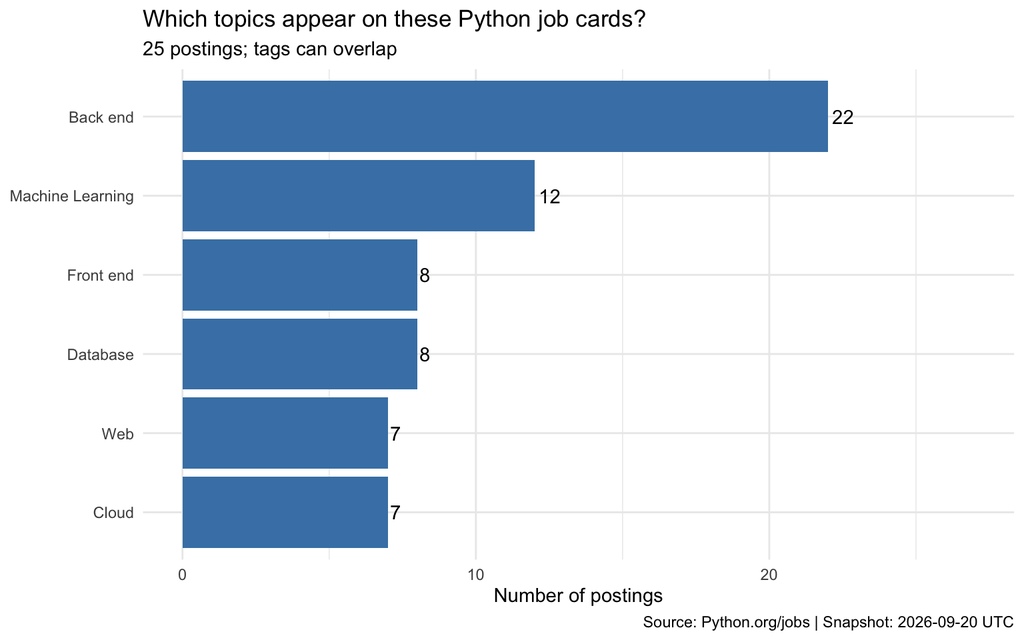

```r
skill_plot <- ggplot(
  skills,
  aes(x = reorder(skill, postings), y = postings)
) +
  geom_col(fill = "steelblue") +
  geom_text(aes(label = postings), hjust = -0.2) +
  coord_flip() +
  scale_y_continuous(limits = c(0, n_total + 2)) +
  labs(
    title = "Which topics appear on these Python job cards?",
    subtitle = paste(n_total, "postings; tags can overlap"),
    x = NULL,
    y = "Number of postings",
    caption = paste(
      "Source: Python.org/jobs | Snapshot:",
      snapshot_date,
      "UTC"
    )
  ) +
  theme_minimal()

#display the figure
skill_plot
```

```r
#save the figure
ggsave(
  filename = here(
    "blog", "posts", "post2",
    "results", "figures", "skill_counts.png"
  ),
  plot = skill_plot,
  width = 8,
  height = 5,
  dpi = 180
)
```

The Back end tag appears in 22 of 25 listings (88%), while Machine Learning appears in 12 (48%). These numbers describe how often the labels occur in this sample.

Backend development means the part of an application that handles requests, processes information, and works with stored data and the tag is a bit broad: it does not identify a particular framework or tell me whether the position is suitable for a beginner.

## Do backend and machine learning appear together?

The ranking tells me which tags are common, but I also want to know whether backend and machine learning appear on the same listings. That matters for the project choice: if employers advertise the two together, I have a reason to explore a project that connects them, such as a classifier inside an application. I use `case_when()` to put each posting into exactly one group and make that overlap easier to see.

```r
overlap <- jobs |>
  mutate(
    group = case_when(
      tags_missing ~ "No tags shown",
      backend & machine_learning ~ "Both backend and ML",
      backend ~ "Backend tag; no ML tag",
      machine_learning ~ "ML tag; no backend tag",
      TRUE ~ "Neither selected tag"
    )
  ) |>
  count(group, name = "postings", sort = TRUE) |>
  mutate(percent = round(100 * postings / n_total, 1))

write.csv(
  overlap,
  here("blog", "posts", "post2", "results", "tables", "topic_overlap.csv"),
  row.names = FALSE
)
```

| Group | Postings | Share of all postings (%) |
| --- | --- | --- |
| Both backend and ML | 12 | 48 |
| Backend tag; no ML tag | 10 | 40 |
| No tags shown | 3 | 12 |

Of the 12 ML-tagged postings, 12 also carry the Back end tag. There are 0 ML-tagged postings without a Back end tag. These categories in the table are mutually exclusive and account for all listings; their percentages sum to approximately 100%, allowing for rounding.

## What I would build next

For my next general Python project, I would start with a small backend application. Backend appears at least as often as ML in this sample, so it is a reasonable area to prioritize when choosing between the two.

I would build an application tracker that lets a user add a job application, update its status, and retrieve saved records. Next, I would connect it to a small database and check how it handles missing or invalid inputs.

The overlap also gives me a reason to connect the two areas. For a project that combines both, I could connect the job description classifier to the application tracker and show its prediction through the application. That would let me practice using a model inside a working application.

This is my proposed learning sequence. The listings do not specifically request an application tracker, a particular database, or one framework. The practical decision is about what to build next, not a claim that one project guarantees employment.

## Limits of the analysis

This is a small, international sample from the first page of one job board and it is not a random sample of Python jobs. So the employers may appear more than once, and different URLs do not necessarily represent different vacancies.

The tags are broad descriptions rather than a complete reading of each job’s requirements as I did not measure experience requirements, salaries, applicant competition, or hiring outcomes. So, I cannot conclude that the postings are entry level jobs or that learning a frequent topic causes a higher chance of receiving an offer.

For someone choosing a Python portfolio project, my recommendation from this snapshot is to start with a small application tracker. A user should be able to save an application, update its status, and retrieve it later. I would get that basic workflow working and write clear instructions for running it before adding a job-description classifier. The overlap between the tags makes that extension worth exploring. If you are making a similar choice, use this as a starting point, then read full descriptions of jobs that interest you to decide which features are worth practicing.

My goal here is to help someone who knows basic Python choose a manageable project for a portfolio. If you are unsure what to make next, the approach is simple: use job tags to narrow your options, read a few full descriptions, and choose one useful task to practice. That gives you a specific next step and something concrete to show others, while leaving room for your own interests and current skills.

## Reproducing the analysis

All of my code and writing are in this post’s index.qmd. The data folder contains the saved webpage, collection metadata, and cleaned dataset. I save the numerical results in results/tables and the chart in results/figures. These results also appear in the blog. With refresh set to FALSE, the analysis uses the saved webpage so someone else can work with the same listings. The repository README explains how to install the packages and run the analysis.

[Code, data, and replication instructions](https://github.com/LeeBABA999/aeds-website.git).

Sources: [Python.org Job Board](https://www.python.org/jobs/), [rvest documentation](https://rvest.tidyverse.org/reference/html_element.html).